# Coding Challenge 1

Kevin Bailey, Yuying(Bella) Guan

March 27, 2019

Loading libraries.

```r
library(boot)   # For CV
library(leaps)  # For regsubsets()
library(glmnet) # For Lasso
library(splines)# For Splines
library(fields) # For Thin-plate splines
```

Put the file location of your test set in the first line and uncomment it, and the training set that we used that you uploaded should be inside of the argument on the second line for data.

```r
test_data <- read.csv("D:/School/Cal Poly/S19/STA 5320/Coding Challenge/challenge1testing.csv")
#data <- read.csv("file:///home/kevin/School/Spring 2019/STA 5320/Coding Challenge/challenge1testing.csv")

data <- read.csv("D:/School/Cal Poly/S19/STA 5320/Coding Challenge/challenge1testing.csv")

data <- data[,-1] # X is just an observation number
data$Quality <- as.factor(data$Quality)
data$Style <- as.factor(data$Style)
```

### Function for Test RSS

```r
# Typical KNN function
KNN <- function(x,K){
  dist <- (x-data$Sqft)^2
  closest <- order(dist)[1:K]
  yhat <- mean(data$Price[closest])

  return(yhat)
}

f <- function(test_set){
  test_set <- test_set[,-1] # X is just an observation number
  test_set$Quality <- as.factor(test_set$Quality)
  test_set$Style <- as.factor(test_set$Style)

  sDummy <- test_set$Style == 7
  test_set$sDummy <- sDummy

  qDummy <- test_set$Quality == 2
  test_set$qDummy <- qDummy

  # -----  Model 1  ----- #
  y <- test_set$Price
  yhat <- predict(backward_model, newdata=test_set)

  cat("-----  Model 1  ----- \n")
  cat("sqrt(LOOCV): ", sqrt(cv.glm(test_set, backward_model)$delta[1]), "\n")
  cat("      LOOCV: ", cv.glm(test_set, backward_model)$delta[1], "\n\n")

  cat("  sqrt(RSS): ", sqrt(sum((y - yhat)^2)), "\n") # sqrt(RSS)
  cat("        RSS: ", sum((y-yhat)^2), "\n\n")
  # cat("  sqrt(MSE): ", sqrt(sum((y - yhat)^2)/nrow(test_set)), "\n") # sqrt(MSE)

  # ----- "Model" 2  ----- #
  yhats <- 0

  for(i in 1:nrow(test_set)){
    yhats[i] <- KNN(test_set$Sqft[i],2)
  }

  cat("----- \"Model\" 2 ----- \n")
  cat("  sqrt(RSS): ", sqrt(sum((y-yhats)^2)), "\n") # sqrt(RSS), just easier to compare
  cat("        RSS: ", sum((y-yhats)^2))
}
```

### Model 1

```r
sDummy <- data$Style == 7
data$sDummy <- sDummy

qDummy <- data$Quality == 2
data$qDummy <- qDummy

backward_model <- glm(Price ~ Sqft + Quality + Lot + Sqft:Bed + Sqft:Year + Year:sDummy + Bath:qDummy, data=data)

summary(backward_model)
```

```
##
## Call:
## glm(formula = Price ~ Sqft + Quality + Lot + Sqft:Bed + Sqft:Year +
##     Year:sDummy + Bath:qDummy, data = data)
##
## Deviance Residuals:
##     Min       1Q   Median       3Q      Max
## -225139   -49707     1513    36407   246886
##
## Coefficients:
##                    Estimate Std. Error t value Pr(>|t|)
## (Intercept)       1.409e+05  5.240e+04   2.689 0.007922 **
## Sqft             -1.329e+03  2.663e+02  -4.990 1.57e-06 ***
## Quality2         -2.732e+05  5.156e+04  -5.299 3.82e-07 ***
## Quality3         -1.819e+05  3.154e+04  -5.766 4.10e-08 ***
## Lot               1.543e+00  5.170e-01   2.985 0.003284 **
## Sqft:Bed         -7.838e+00  2.254e+00  -3.477 0.000655 ***
## Sqft:Year         7.502e-01  1.353e-01   5.544 1.21e-07 ***
## Year:sDummyTRUE  -2.633e+01  7.822e+00  -3.366 0.000956 ***
## Bath:qDummyFALSE -9.978e+03  1.012e+04  -0.986 0.325785
## Bath:qDummyTRUE   4.142e+04  1.249e+04   3.317 0.001128 **
## ---
## Signif. codes:  0 '***' 0.001 '**' 0.01 '*' 0.05 '.' 0.1 ' ' 1
##
## (Dispersion parameter for gaussian family taken to be 6068169640)
##
##     Null deviance: 5.2719e+12  on 168  degrees of freedom
## Residual deviance: 9.6484e+11  on 159  degrees of freedom
## AIC: 4298.2
##
## Number of Fisher Scoring iterations: 2
```

```r
#par(mfrow=c(2,2))
#plot(backward_model)

# change data to test_set
cat("sqrt(LOOCV): ", sqrt(cv.glm(data, backward_model)$delta[1]))
```

```
## sqrt(LOOCV):  81354.27
```

```r
y <- data$Price # Change data to test_set
yhat <- predict(backward_model, newdata=data) # Replace data with test_set
sqrt(sum((y - yhat)^2)) # sqrt(RSS)
```

```
## [1] 982262.2
```

```r
# Replace data with test_set
sqrt(sum((y - yhat)^2)/nrow(data)) # Dividing by observations to get MSE, more comparable for LOOCV.
```

```
## [1] 75558.63
```

We ended up choosing the model with interaction terms from Backward Selection, with the predictors as stated above. We tried many different linear models, including Best Subset Selection without interaction terms(and tried it with interaction terms, but it wouldn’t finish running), linear models with all predictors, Lasso and Ridge both with/without interaction terms, Forward Selection with interaction terms, and more that weren’t detailed here. We did not use any polynomial terms as the residuals showed only a slight funnel, addressed in the next paragraph, but the QQ-Plot wasn’t exactly perfect although it was not the worst. This model also had the best AIC/BIC, and although the Adjusted $R^2$ for every model isn’t amazing, this model seemed to come out on top in all of the areas mentioned.

### Model 2

```r
KNN <- function(x,K){
  dist <- (x-data$Sqft)^2
  closest <- order(dist)[1:K]
  yhat <- mean(data$Price[closest])
  return(yhat)
}
yhats <- 0

# Change both instances of data to test_set for the for loop.
for(i in 1:nrow(data)){
  yhats[i] <- KNN(data$Sqft[i],2)
}

# plot(data$Sqft,data$Price)
# points(data$Sqft,yhats,col="blue")

y <- data$Price # Change data here to test_set
sqrt(sum((y-yhats)^2)) # sqrt(RSS), just easier to compare
```

```
## [1] 965549.9
```

For the nonparametric methods, we decided on KNN with K=2 and Sqft as our one predictor, as it resulted in the lowest RSS. We looked at using other predictors such Lot, Bath, Bed, Quality, etc. but Sqft had the lowest RSS by a good margin. With regards to Splines vs KNN, we did similar for Splines but saw the best results when still with KNN and K=2, no matter the predictor(comparing to Sqft for KNN).

Thin Plate Splines were considered but since we could only use one predictor, it didn’t really do much for us. We also looked at transforming the data but again the results were not the best and we had extra room for error in doing the transform and exponentiating it back. We didn’t want to risk it as our KNN RSS seemed decent as it is. Sorry. :(

```r
f(test_data)
```

```
## -----  Model 1  -----
## sqrt(LOOCV):  81354.27
##       LOOCV:  6618517905
##
##   sqrt(RSS):  982262.2
##         RSS:  9.64839e+11
##
## ----- "Model" 2 -----
##   sqrt(RSS):  965549.9
##         RSS:  932286578936
```

### Some work for Model 1

Best Subset Selection:

```r
m1 <- regsubsets(Price ~ ., data=data, nvmax=17) # BSS.
summary(m1) # Seeing which variables are best.
```

```
## Subset selection object
## Call: regsubsets.formula(Price ~ ., data = data, nvmax = 17)
## 19 Variables  (and intercept)
##            Forced in Forced out
## Sqft           FALSE      FALSE
## Bed            FALSE      FALSE
## Bath           FALSE      FALSE
## Air            FALSE      FALSE
## Garage         FALSE      FALSE
## Pool           FALSE      FALSE
## Year           FALSE      FALSE
## Quality2       FALSE      FALSE
## Quality3       FALSE      FALSE
## Style2         FALSE      FALSE
## Style3         FALSE      FALSE
## Style4         FALSE      FALSE
## Style5         FALSE      FALSE
## Style6         FALSE      FALSE
## Style7         FALSE      FALSE
## Lot            FALSE      FALSE
## Highway        FALSE      FALSE
## sDummyTRUE     FALSE      FALSE
## qDummyTRUE     FALSE      FALSE
## 1 subsets of each size up to 17
## Selection Algorithm: exhaustive
##           Sqft Bed Bath Air Garage Pool Year Quality2 Quality3 Style2
## 1  ( 1 )  "*"  " " " "  " " " "    " "  " "  " "      " "      " "
## 2  ( 1 )  "*"  " " " "  " " " "    " "  "*"  " "      " "      " "
## 3  ( 1 )  "*"  " " " "  " " " "    " "  " "  "*"      "*"      " "
## 4  ( 1 )  "*"  " " " "  " " " "    " "  "*"  " "      "*"      " "
## 5  ( 1 )  "*"  " " " "  " " " "    " "  "*"  "*"      "*"      " "
## 6  ( 1 )  "*"  " " " "  " " " "    " "  "*"  "*"      "*"      " "
## 7  ( 1 )  "*"  "*" " "  " " " "    " "  "*"  " "      "*"      " "
## 8  ( 1 )  "*"  "*" " "  " " " "    " "  "*"  " "      "*"      " "
## 9  ( 1 )  "*"  "*" " "  " " " "    " "  "*"  "*"      "*"      " "
## 10  ( 1 ) "*"  "*" " "  " " " "    " "  "*"  "*"      "*"      " "
## 11  ( 1 ) "*"  "*" " "  " " " "    " "  "*"  "*"      "*"      "*"
## 12  ( 1 ) "*"  "*" "*"  " " " "    " "  "*"  "*"      "*"      "*"
## 13  ( 1 ) "*"  "*" "*"  " " "*"    " "  "*"  "*"      "*"      "*"
## 14  ( 1 ) "*"  "*" "*"  " " "*"    "*"  "*"  "*"      "*"      "*"
```

[output cut: 24 more lines]

```
## 3  ( 1 )  " "
## 4  ( 1 )  "*"
## 5  ( 1 )  " "
## 6  ( 1 )  " "
## 7  ( 1 )  "*"
## 8  ( 1 )  "*"
## 9  ( 1 )  " "
## 10  ( 1 ) " "
## 11  ( 1 ) " "
## 12  ( 1 ) " "
## 13  ( 1 ) " "
## 14  ( 1 ) " "
## 15  ( 1 ) " "
## 16  ( 1 ) " "
## 17  ( 1 ) "*"
```

```r
which(summary(m1)$bic == min(summary(m1)$bic)) # Shows 6 predictor model, bic = -222.6373
```

```
## [1] 6
```

```r
which(summary(m1)$adjr2 == max(summary(m1)$adjr2)) # Shows 11 predictor model, adjr2 = 0.788
```

```
## [1] 11
```

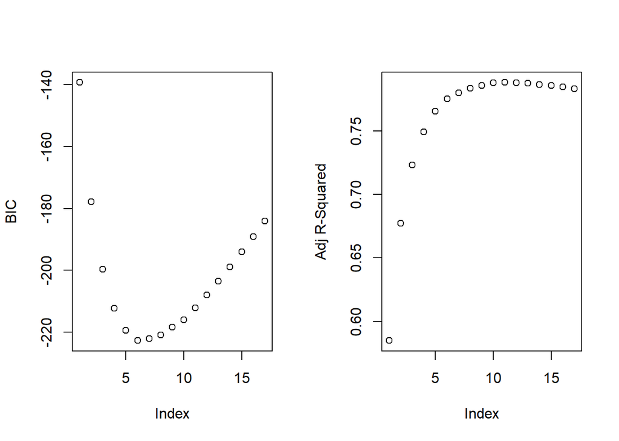

```r
par(mfrow = c(1,2))
plot(summary(m1)$bic, ylab="BIC")
plot(summary(m1)$adjr2, ylab="Adj R-Squared")
```

```r
# The plots above show that the adjusted R-squared doesn't really increase much even after 6 predictors.
# However, after 6 predictors for BIC, 11 predictors is a decent jump up. So I think we should look at the 6 predictor model.
coef(m1, 6)
```

```
##   (Intercept)          Sqft          Year      Quality2      Quality3
## -4.034066e+06  1.123488e+02  2.108944e+03 -1.135610e+05 -1.440431e+05
##        Style7           Lot
## -5.164882e+04  1.609692e+00
```

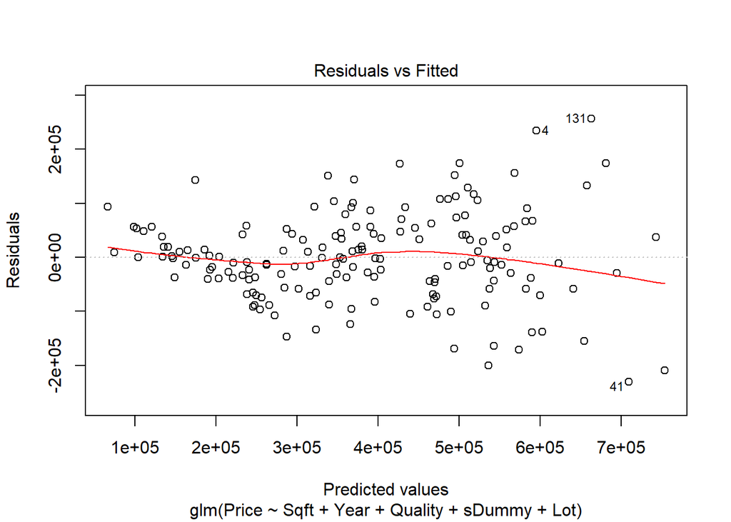

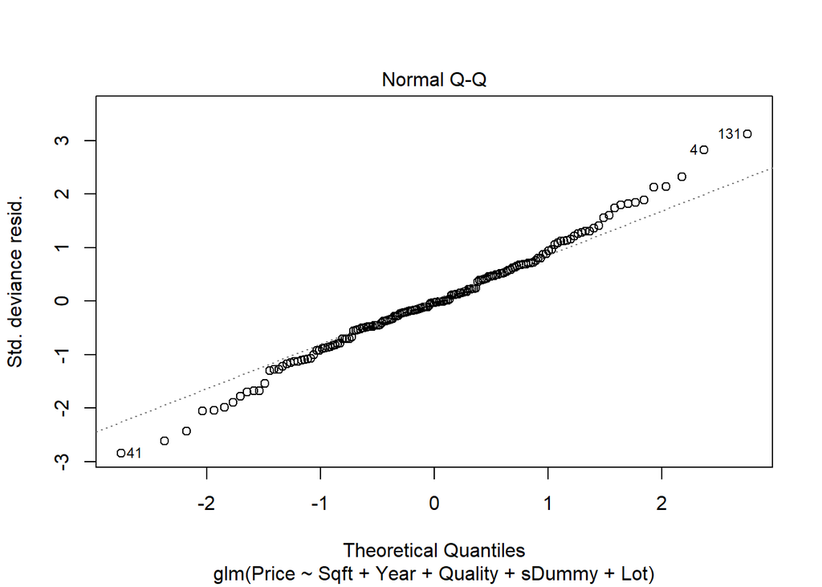

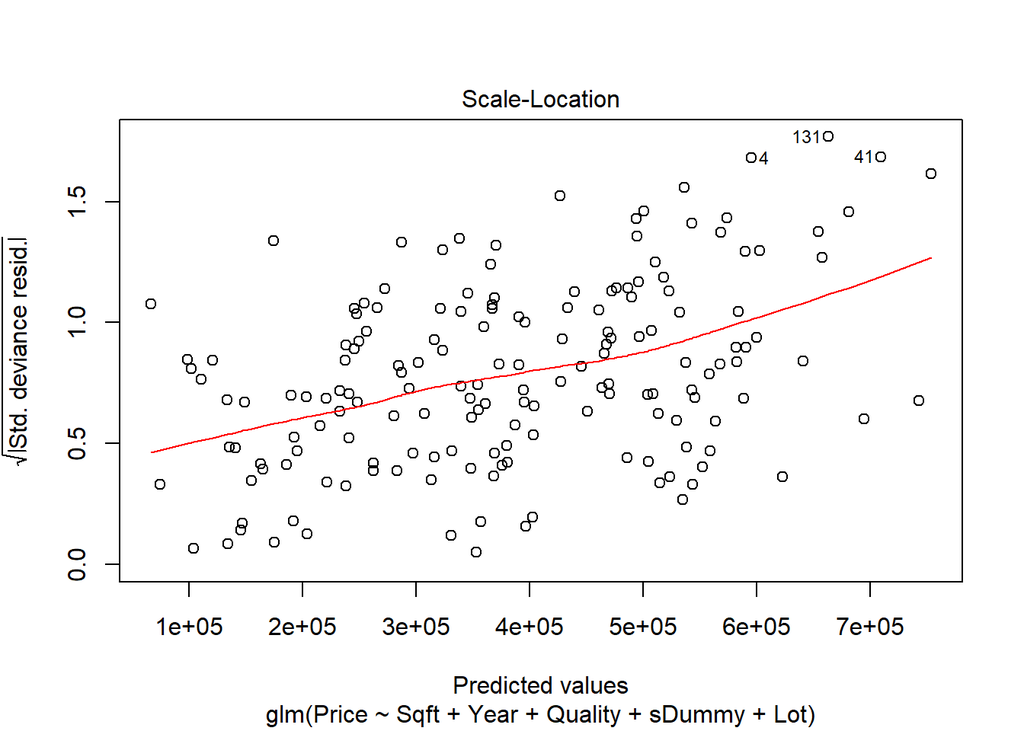

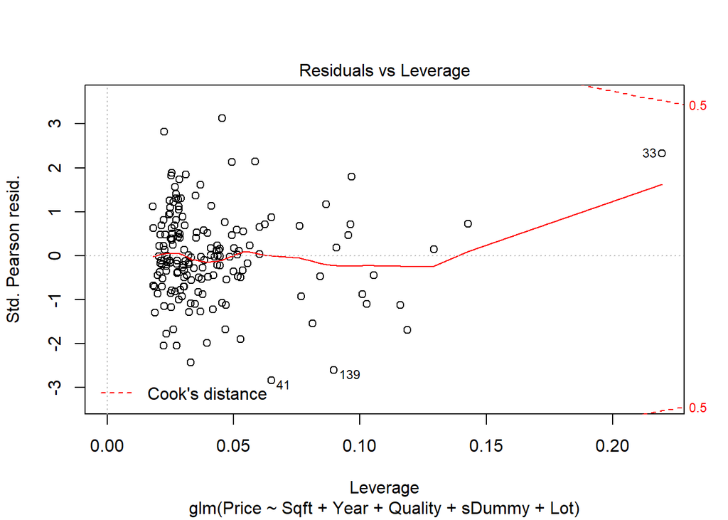

```r
# Including the dummy variable only slightly improved the model.
bss_model <- glm(Price ~ Sqft + Year + Quality + sDummy + Lot, data=data) # Using glm for CV later.
par(mfrow=c(1,1))
plot(bss_model) # Everything looks okay aside from the QQ-Plot. May not need polynomial terms.
```